# Seoul Bike Sharing Demand

STAT 420, Summer 2022, Scott Downey, Sushma Ponna, William Shih

# 1 Introduction

Rental bikes and bike sharing are important in urban cities as bikes reduce traffic congestion, reduce air pollution, and improve last mile transportation. Bikes will become even more important in the future as cities urbanize and have high population densities. The goal of this project is to build a model that will accurately predict the volume of bike rentals at a given time. Predicting exactly many bikes to provide makes sure that there will be no shortage of bikes that would result in people waiting for a bike yet also not have a large surplus of bikes as that would be a waste of resources.

The data set contains bike sharing data in Seoul from 12/1/2017 to 11/30/2018. Each observation represents an hour of time. The variable of interest for prediction is the rented bike count for the hour. The 12 variables that will be considered as predictors include the hour of day, temperature, humidity, wind speed, visibility, dew point, solar radiation, rainfall, snowfall, season of year, holiday (boolean), and functioning (boolean). The dataset is associated with two papers published in a journal in February and March 2020 related to gradient tree boosting, but here we’ll be only using linear regression. and is found at the Seoul government website http://data.seoul.go.kr/

A further description of the dataset can be found at https://archive.ics.uci.edu/ml/datasets/Seoul+Bike+Sharing+Demand

# 2 Methods

We began by importing and cleaning the raw data from the dataset described above. As part of this, we transformed several predictors into Factor and Integer variables. We also broke out the ‘Date’ field into ‘Day’, ‘Month’ and ‘Year’. We eventually discarded the ‘Year’ predictor, as our model will be focused on predicting usage for future years (and this will enable a ‘year agnostic’ model to predict usage regardless of yearly data).

```r
#Load the bike sharing data into R
require(dplyr)
library(tidyr)
library(ggplot2)
library(kableExtra)
colnames = c("Date","RentedBikeCount","Hour","Temperature","Humidity","Wind","Visibility",
             "DewPoint","SolarRadiation","Rainfall","Snowfall","Season","Holiday","Functional")
data = read.csv("https://archive.ics.uci.edu/ml/machine-learning-databases/00560/SeoulBikeData.csv",
                col.names = colnames)
data = tibble(data)

#Separate 'Date'  into Day, Month and Year
data = separate(data, "Date", c("Day", "Month", "Year"))

#Convert predictors to factors or integers as needed
data$Season = as.factor(data$Season)
data$Holiday = as.factor(data$Holiday)
data$Functional = as.factor(data$Functional)

data$Day = as.integer(data$Day)
data$Month = as.integer(data$Month)
data$Year = as.integer(data$Year)

#Remove 'Year' as this won't be a good predictor for future years
data = dplyr::select(data, -Year)
```

We investigated the data, particularly how predictors related to each other through collinearity. Below is a correlation plot describing each. Temperature and (to a lesser degree) Humidity both had high correlation to Dewpoint.

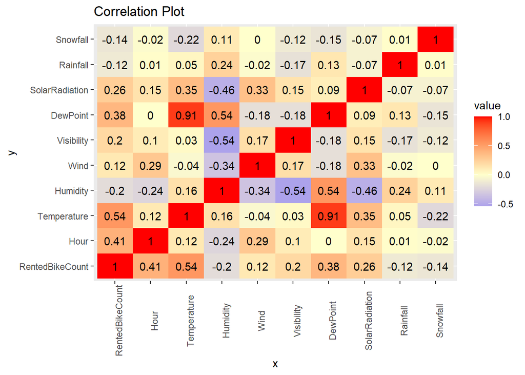

Figure 2.1: Fig-1

```r
correlations = round(cor(data %>% select(-c(Day, Month, Season, Holiday, Functional))), 2)
cor_melt = reshape2::melt(correlations)
ggplot(cor_melt, aes(x = Var1, y = Var2, fill = value)) +
  geom_tile() +
  theme(axis.text.x = element_text(angle = 90)) +
  xlab("x") + ylab("y") + ggtitle("Correlation Plot") +
  scale_fill_gradient2(low = "#075AFF",
                       mid = "#FFFFCC",
                       high = "#FF0000") +
  geom_label(aes(label = value), color = "black", label.size = NA)
```

We looked at the response ‘RentedBikeCount’ as it relates to the various predictors we have available. Below we compared time and date (Day, Month and Hour), as well as environment predictors like temperature, humidity, rainfall, snowfall, solar radiation, etc.

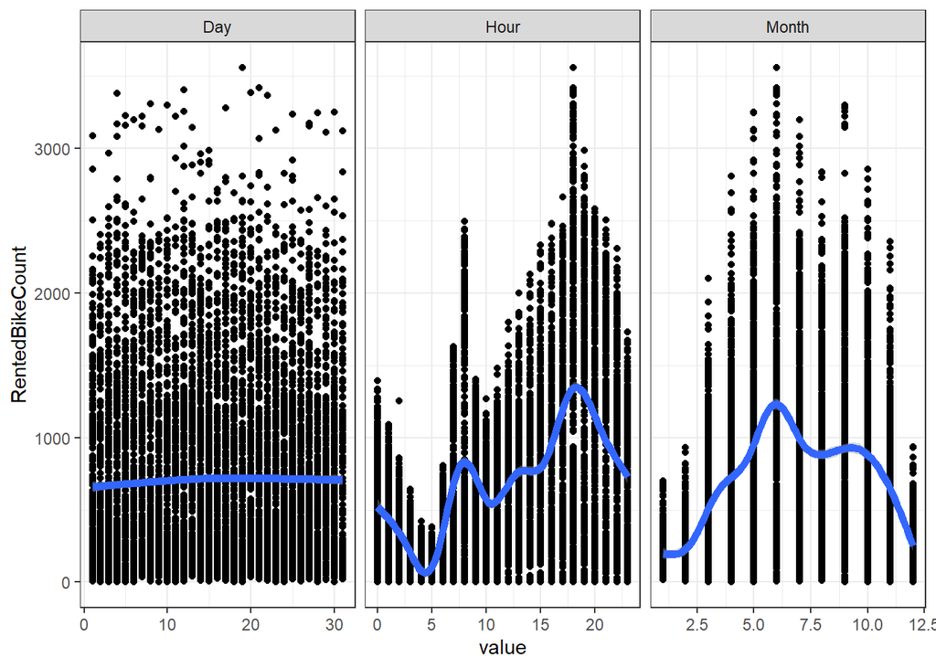

Figure 2.2: Fig-2

```r
draw_plot = function(data){
  data %>%
    gather(-RentedBikeCount, key = "xaxis", value = "value") %>%
    ggplot(aes(x = value, y = RentedBikeCount)) +
    geom_point() + theme_bw() +
    stat_smooth(geom = "smooth", size = 2, level = 0.95) +
    facet_wrap(xaxis ~ ., scales = "free_x")
}
draw_plot(data %>% select(RentedBikeCount, Hour, Day, Month))
```

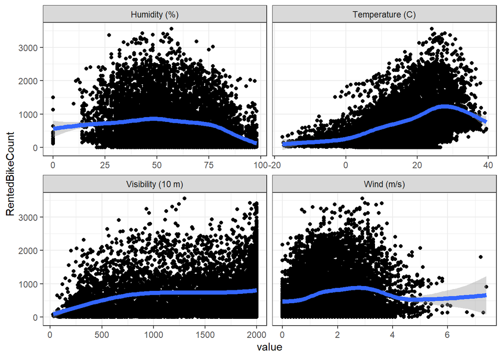

Figure 2.3: Fig-3

```r
draw_plot(data %>% select(RentedBikeCount, Temperature, Humidity, Wind, Visibility) %>%
  rename(`Humidity (%)` = Humidity, `Temperature (C)` = Temperature, `Wind (m/s)` = Wind, `Visibility (10 m)` = Visibility))
```

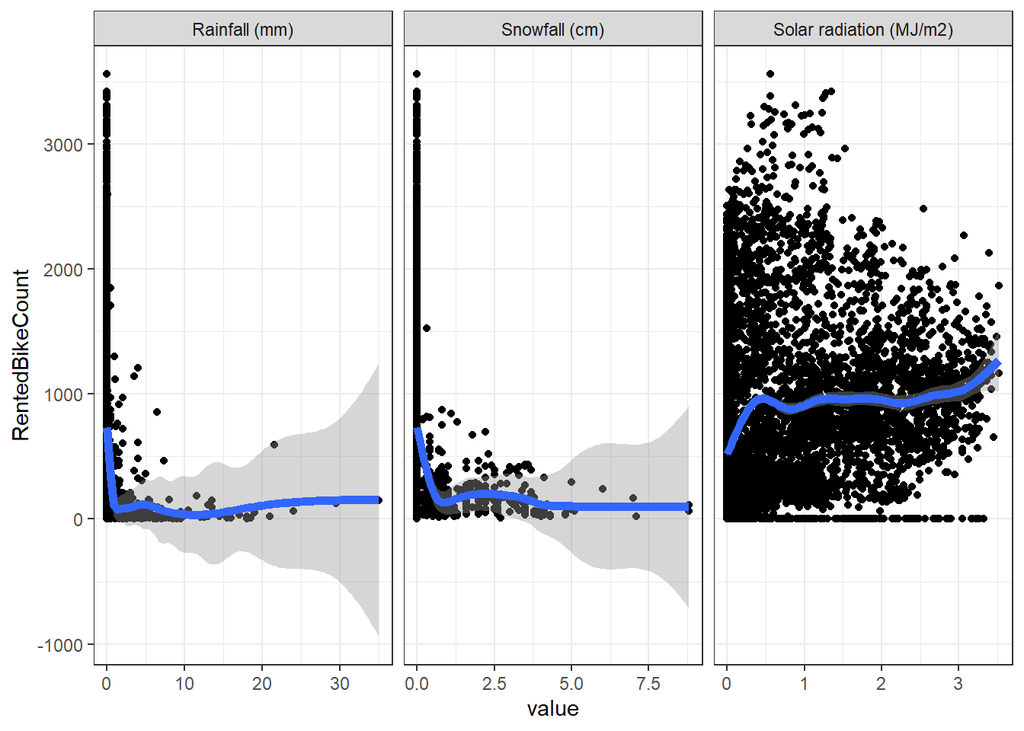

Figure 2.4: Fig-4

```r
draw_plot(data %>% select(RentedBikeCount, SolarRadiation, Rainfall, Snowfall) %>%
  rename(`Solar radiation (MJ/m2)` = SolarRadiation, `Rainfall (mm)` = Rainfall, `Snowfall (cm)` = Snowfall))
```

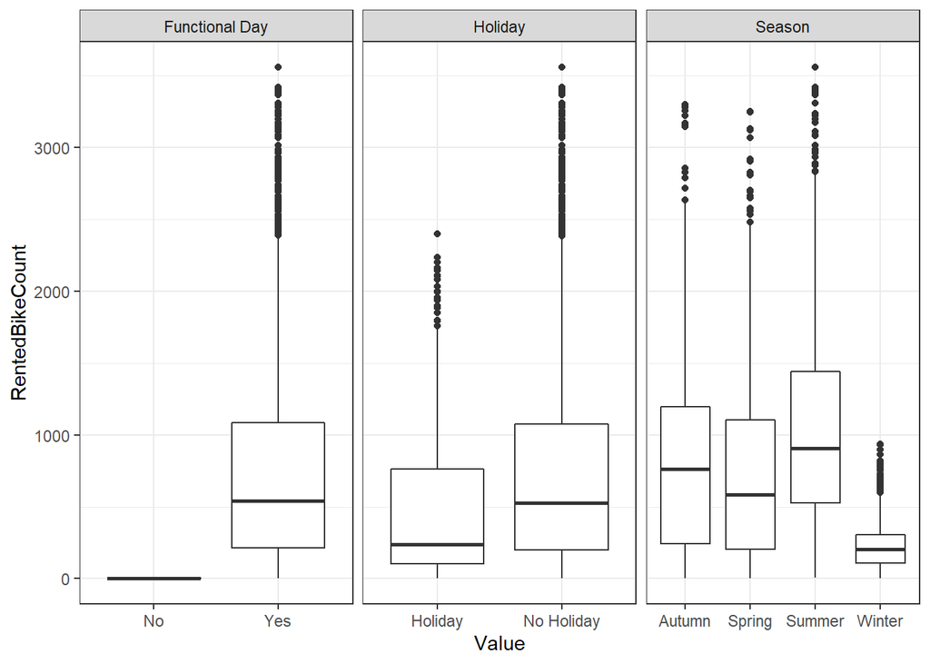

Figure 2.5: Fig-5

```r
data %>%
  select(RentedBikeCount, Season, Holiday, Functional) %>%
  rename(`Functional Day` = Functional) %>%
  pivot_longer(., -RentedBikeCount, names_to = "Variable", values_to = "Value") %>%
  ggplot(aes(x = Value, y = RentedBikeCount)) + theme_bw() +
    geom_boxplot() +
    facet_wrap(. ~ Variable, scales = "free_x")
```

The `evaluate` function below is for generating the data for Table 3.1 and the top half of Table 3.3. The `evaluate_power` function is for generating the the data for bottom half of Table 3.3. The `get_table` formats two tables. The `transformation_power` function is for generating the data for Table 3.2.

```r
#Function to calculate LOOCV-RMSE
get_loocv_rmse = function(model) {
  sqrt(mean((resid(model) / (1 - hatvalues(model))) ^ 2))
}
#Function to calculate Test RMSE
get_rmse = function(model, power = 1){
  pred = predict(model, bike_tst)^power
  actual = bike_tst$RentedBikeCount
  n = length(pred)
  sqrt(1/n * sum((actual-pred)^2))
}
#Function to return R^2
get_R2 = function(model){
  cor(predict(model, bike_tst), bike_tst$RentedBikeCount)^2
}
#Function to return Adjusted R^2
get_R2_adj = function(model, power){
  factor = summary(model)$adj.r.squared/summary(model)$r.squared
  cor(predict(model, bike_trn)^power, bike_trn$RentedBikeCount)^2
}
#Function to evaluate the list of models with metrics chosen
evaluate = function(models, row_names){
  num_coefs = sapply(models, function(x) length(coef(x)))
  loocv_rmse = sapply(models, get_loocv_rmse)
  bics_list = unlist(sapply(models, AIC, k = log(6132)))
  rmse_list = sapply(models, get_rmse)
  R2test_list = sapply(models, get_R2)
  R2adj_list = sapply(models, function(x) summary(x)$adj.r.squared)
  frame = cbind(num_coefs, loocv_rmse, bics_list, rmse_list, R2adj_list, R2test_list)
  colnames(frame) = c("Coefficients", "LOOCV-RMSE","BIC","Test RMSE","Adjusted R2","Test R2")
  rownames(frame) = row_names
  return(frame)
}
#Function to evaluate the list of models with metrics chosen with given power
evaluate_power = function(models, power = 0.5, row_names){
  num_coefs = sapply(models, function(x) length(coef(x)))
  loocv_rmse = sapply(models, get_loocv_rmse)
  bics_list = unlist(sapply(models, AIC, k = log(6132)))
  rmse_list = sapply(models, get_rmse, power = 1/power)
  R2test_list = sapply(models, function(model) cor(predict(model, bike_tst)^(1/power), bike_tst$RentedBikeCount))^2
  R2adj_list = sapply(models, get_R2_adj, power = 1/power)
  frame = cbind(num_coefs, loocv_rmse, bics_list, rmse_list, R2adj_list, R2test_list)
  colnames(frame) = c("Coefficients", "LOOCV-RMSE","BIC","Test RMSE","Adjusted R2","Test R2")
  rownames(frame) = row_names
  return(frame)
}
#Function to provide data in a table format
get_table = function(frame, title){
  # Minimum for 2,3,4
  # Maximum for 5,6
  kable(frame, digits = c(0,1,1,1,3,3), caption = title, format.args = list(big.mark = ",")) %>%
    column_spec(3, bold = (frame[,2] == min(frame[,2]))) %>%
    column_spec(4, bold = (frame[,3] == min(frame[,3]))) %>%
    column_spec(5, bold = (frame[,4] == min(frame[,4]))) %>%
    column_spec(6, bold = (frame[,5] == max(frame[,5]))) %>%
    column_spec(7, bold = (frame[,6] == max(frame[,6]))) %>%
    kable_styling(bootstrap_options = c("striped", "hover", "bordered", "condensed", "responsive"))
}
#Helper function to plot diagnostics
plot_diagnostics = function(model, title){
  require(ggplot2)
  require(grid)
  require(gridExtra)
    pcol = "grey"
    lcol = "dodgerblue"
    data1 = data.frame(Fitted = fitted(model), Residuals = resid(model))
    plot1 = ggplot(data1, aes(x = Fitted, y = Residuals)) +
      geom_point(color = pcol) + theme_bw() + geom_hline(yintercept = 0, color = lcol) +
      stat_smooth() +
      ggtitle(paste("Fitted vs Residuals for\n",title))
    plot2 = ggplot(data1, aes(sample = Residuals)) +
      stat_qq(color = pcol) + stat_qq_line(color = lcol) + theme_bw() +
      xlab("Theoretical Quantiles") + ylab("Sample Quantiles") +
      ggtitle(paste("Normal Q-Q Plot for\n",title))
    arrangeGrob(plot1, plot2, nrow = 1, ncol = 2)
}

transformation_power = function(pow, form){
  temp_data = bike_trn
  temp_data$RentedBikeCount = temp_data$RentedBikeCount^pow
  model = lm(form, data = temp_data)
  R2_factor = summary(model)$adj.r.squared/summary(model)$r.squared
  actual_test = bike_tst$RentedBikeCount
  pred_test = (pmax(predict(model, bike_tst), 0))^(1/pow)
  pred_train = (pmax(predict(model, bike_trn), 0))^(1/pow)
  n = length(pred_test)
  c(Adj_R2 = cor(pred_train, bike_trn$RentedBikeCount)^2*R2_factor,
         Test_RMSE = sqrt(1/n * sum((actual_test-pred_test)^2)))
}
```

We then split our data into ‘Train’ and ‘Test’ data sets. We used a 70/30 split Train/Test, where we would build our model on the ‘Train’ data and test its performance on the ‘Test’ dataset.

```r
#Split data into training and test data
set.seed(42)
trn_size = as.integer(0.7 * count(data))
trn_idx = sample(nrow(data), trn_size)
bike_trn = data[trn_idx, ]
bike_tst = data[-trn_idx, ]
```

We began with several initial models - an multiple linear regressions (MLR) additive model and several interaction models, ending will a “full” interaction model with all two-way interaction between the predictors. We decided to use three metrics to test the validity of variable subset selection: LOOCV-RMSE, BIC and Test RMSE.

```r
#Initial model starting points
model_add = lm(RentedBikeCount ~ ., data = bike_trn)
model_fact = lm(RentedBikeCount ~ . + factor(Hour), data = bike_trn)
model_fact2 = lm(RentedBikeCount ~ . + factor(Hour) + (Temperature * .), data = bike_trn)
model_fact3 = lm(RentedBikeCount ~ . + factor(Hour) + (Temperature * .) + (Hour*.), data = bike_trn)
model_fact4 = lm(RentedBikeCount ~ . + factor(Hour) + (Temperature * .) + (Humidity*.) + (Hour*.), data = bike_trn)
model_fact5 = lm(RentedBikeCount ~ (.)^2 + factor(Hour), data = bike_trn)
continuous = c("Day","Hour","Temperature","Humidity","Wind","Visibility","DewPoint","SolarRadiation","Rainfall","Snowfall")
full_formula = as.formula(
    paste0('RentedBikeCount ~ (.)^2 + factor(Hour) + ', paste0('I(',continuous,'^2)*.',collapse = ' + ')))
model_fact6 = lm(RentedBikeCount ~ (.)^2 + factor(Hour) + I(Temperature^2)*. + I(Wind^2)*., data = bike_trn)
model_full = lm(full_formula, data = bike_trn)
models = list(model_add, model_fact, model_fact2, model_fact3, model_fact4, model_fact5, model_fact6, model_full)
```

```r
frame = evaluate(models, row_names = c("Additive","Hour as Factor","Interaction with Temp",
                    "Interaction with Temp,Hour","Interaction with Temp,Humidity,Hour",
                    "All Interaction", "All Interaction (Quadratic for Wind/Temp)", "All Interaction with Quadratics"))
table_eval1 = get_table(frame, title = "Evaluation of Initial Models")
```

Once we selected the initial model we liked best based on the metrics above, we ran this through AIC and BIC procedures in an attempt to simplify the model without sacrificing accuracy to a material degree.

```r
#aic_model = step(model_fact7, direction = "backward", trace = 0)
#bic_model = step(model_fact7, span = RentedBikeCount ~ 1, direction = "backward", k = log(trn_size), trace = 0)
#aic_formula = aic_model$terms
#bic_formula = bic_model$terms
#anova(bic_model, bic_model2)

aic_formula = formula(RentedBikeCount ~ Day + Month + Hour + Temperature + Humidity +
     Wind + Visibility + DewPoint + SolarRadiation + Rainfall +
     Snowfall + Season + Holiday + Functional + factor(Hour) +
     I(Temperature^2) + I(Wind^2) + Day:Month + Day:Humidity +
     Day:Wind + Day:Visibility + Day:SolarRadiation + Day:Season +
     Day:Holiday + Month:Temperature + Month:Visibility + Month:DewPoint +
     Month:SolarRadiation + Month:Season + Month:Holiday + Month:Functional +
     Hour:Temperature + Hour:Humidity + Hour:Wind + Hour:Visibility +
     Hour:DewPoint + Hour:SolarRadiation + Hour:Rainfall + Hour:Snowfall +
     Hour:Season + Hour:Holiday + Hour:Functional + Temperature:Wind +
     Temperature:Visibility + Temperature:DewPoint + Temperature:SolarRadiation +
     Temperature:Rainfall + Temperature:Season + Humidity:Wind +
     Humidity:Visibility + Humidity:DewPoint + Humidity:SolarRadiation +
     Humidity:Rainfall + Humidity:Season + Humidity:Holiday +
     Humidity:Functional + Wind:Visibility + Wind:DewPoint + Wind:SolarRadiation +
     Wind:Season + Visibility:DewPoint + Visibility:SolarRadiation +
     DewPoint:SolarRadiation + DewPoint:Rainfall + DewPoint:Season +
     DewPoint:Functional + SolarRadiation:Season + SolarRadiation:Functional +
     Rainfall:Snowfall + Rainfall:Season + Season:Holiday + Season:Functional +
     Holiday:Functional + Day:I(Temperature^2) + Month:I(Temperature^2) +
     Wind:I(Temperature^2) + DewPoint:I(Temperature^2) + Rainfall:I(Temperature^2) +
     Season:I(Temperature^2) + Holiday:I(Temperature^2) + Hour:I(Wind^2) +
     Temperature:I(Wind^2) + Humidity:I(Wind^2) + Wind:I(Wind^2) +
     Visibility:I(Wind^2) + DewPoint:I(Wind^2) + Rainfall:I(Wind^2) +
     Snowfall:I(Wind^2) + Season:I(Wind^2))
bic_formula = formula(RentedBikeCount ~ Day + Month + Hour + Temperature + Humidity +
     Wind + Visibility + DewPoint + SolarRadiation + Rainfall +
     Snowfall + Season + Holiday + Functional + factor(Hour) +
     I(Temperature^2) + I(Wind^2) + Day:Holiday + Month:Temperature +
     Month:DewPoint + Month:Season + Month:Holiday + Hour:Temperature +
     Hour:Humidity + Hour:Wind + Hour:DewPoint + Hour:SolarRadiation +
     Hour:Rainfall + Hour:Holiday + Hour:Functional + Temperature:Visibility +
     Temperature:DewPoint + Temperature:Rainfall + Temperature:Season +
     Humidity:Visibility + Humidity:DewPoint + Humidity:SolarRadiation +
     Humidity:Season + Humidity:Functional + Wind:SolarRadiation +
     Wind:Rainfall + Wind:Season + Visibility:DewPoint + DewPoint:SolarRadiation +
     DewPoint:Rainfall + DewPoint:Season + DewPoint:Functional +
     SolarRadiation:Functional + Rainfall:Snowfall + Season:Holiday +
     Day:I(Temperature^2) + Month:I(Temperature^2) + DewPoint:I(Temperature^2) +
     Rainfall:I(Temperature^2) + Season:I(Temperature^2) + Holiday:I(Temperature^2) +
    Hour:I(Wind^2) + Season:I(Wind^2))
aic_model = lm(aic_formula, data = bike_trn)
bic_model = lm(bic_formula, data = bike_trn)
```

The BIC model was only slightly worse than the AIC model while lowering the number of parameters from 140 to 99 so the model selected from backward stepwise regression using BIC was the initial choice of model.

```r
plot_diag1 = plot_diagnostics(bic_model, "BIC Model with no Transform")
```

The residuals of the BIC model do not show constant variance and shows a typical situation (as the response variable is bounded by 0 and no upper bound) where the variance is higher when the predicted value is higher so try a transformation of the response variable where the power is below 1. Note a log transformation is inappropriate due to the presence of many 0 values.

```r
bike_shift = bike_trn
bike_shift$RentedBikeCount = bike_shift$RentedBikeCount + 1
bic_one = lm(bic_formula, data = bike_shift)
bc = MASS::boxcox(bic_one, lambda = seq(-0.8, 1.2, 0.02), plotit = FALSE)
best_lambda = bc$x[which.max(bc$y)]
plot_boxcox = ggplot(data.frame(lambda = bc$x, like = bc$y), aes(x = lambda, y = like)) +
  geom_line(size = 2) + xlab("Lambda") + ylab("Log-Likelihood") +
  geom_vline(aes(xintercept = best_lambda, color = "Max"), size = 2) + theme_bw() +
  geom_vline(aes(xintercept = 0.5, color = "Square Root"), size = 2) +
  geom_vline(aes(xintercept = 1, color = "Linear"), size = 2) +
  ggtitle("BoxCox Plot")
```

Below, we compute the adjusted $R^{2}$ and Test RMSE when transforming the response variable (testing powers of 0.2-1.0 in increments of 0.1 on the response variable). Note the adjusted $R^{2}$ was calculated using the $R^{2}$ of the back transformed predicted values and then multiplied by a factor `summary(model)$adj.r.squared/summary(model)$r.squared`. Table 3.3 shows that a square root transformation actually improves the test RMSE and adjusted $R^{2}$ while giving the residuals closer to constant variance.

```r
try_powers = seq(0.2,1,0.1)
power_RMSE = t(sapply(seq(0.2,1,0.1), transformation_power, form = bic_formula))
colnames(power_RMSE) = c("Adjusted R^2","Test RMSE")
rownames(power_RMSE) = try_powers
table_transform = kable(power_RMSE, digits = c(3,1), caption = "Adjusted R^2 and Test RMSE using power transformations of response variable of BIC model (Predictions Clamped at 0)") %>%
  column_spec(2, bold = power_RMSE[,1] == max(power_RMSE[,1])) %>% column_spec(3, bold = power_RMSE[,2] == min(power_RMSE[,2])) %>%
  kable_styling(bootstrap_options = c("striped", "hover", "bordered", "condensed", "responsive"))
```

```r
bic_sqrt = lm(update(bic_formula, sqrt(.) ~ . ), data = bike_trn)
```

The `bic_sqrt` model has the same exact parameters as the model selected from backward step wise regression using BIC (full model was `model_fact6`). The best model `best_model` below was found manually after removing some parameters that not logical to be there from the `bic_sqrt_full` model and is between the `bic_sqrt` and `bic_sqrt_full` model in complexity and number of parameters.

```r
bic_sqrt_full = lm(sqrt(RentedBikeCount) ~ (.)^2 + factor(Hour) + I(Day^2) * . +
    I(Hour^2) * . + I(Temperature^2) * . + I(Humidity^2) * . +
    I(Wind^2) * . + I(Visibility^2) * . + I(DewPoint^2) * . +
    I(SolarRadiation^2) * . + I(Rainfall^2) * . + I(Snowfall^2) * ., data = bike_trn)
best_formula = formula(sqrt(RentedBikeCount) ~ .-Day + factor(Hour) +
      I(Temperature^2) + I(Humidity^2) + I(Wind^2) +
      I(Visibility^2) + I(DewPoint^2) + I(SolarRadiation^2) + I(Rainfall^2) +
      I(Snowfall^2) + Month:(Season + Holiday) +
      Hour:(Temperature + Humidity + Visibility + SolarRadiation + Rainfall + Season + Holiday + Functional) +
      Temperature:(Humidity + DewPoint + SolarRadiation + Rainfall + Season + Holiday + Functional) +
      Humidity:(Visibility + DewPoint + Rainfall + Holiday + Functional) +
      Wind:(Visibility + DewPoint) + Visibility:Rainfall +
      DewPoint:(Rainfall + Season + Functional) +
      SolarRadiation:Holiday + Rainfall:Functional + Season:Holiday +
            I(Hour^2):(Temperature + Season) + I(Hour^3):Temperature +
      I(Temperature^2):(Temperature + Humidity + DewPoint + Rainfall + Season) +
      I(Humidity^2):(Hour + Temperature + Humidity + Wind + Functional) +
      I(Wind^2):(Humidity + Visibility + DewPoint) +
      I(Visibility^2):(Hour + Temperature + Humidity + Visibility + DewPoint + Rainfall) +
      I(DewPoint^2):(Humidity + DewPoint + SolarRadiation + Rainfall) +
      I(SolarRadiation^2):(SolarRadiation + Rainfall + Holiday) +
      I(Rainfall^2):(Temperature + Humidity + DewPoint + SolarRadiation + Rainfall + Functional) +
      I(Snowfall^2):(Wind + Visibility + Snowfall))
best_model = lm(best_formula, data = bike_trn)

sqrt_models = list(bic_sqrt, best_model, bic_sqrt_full)
frame2_sqrt = evaluate_power(sqrt_models, power = 0.5, c("BIC Sqrt","BIC Sqrt Optimal", "BIC Sqrt Full"))

models = list(model_fact6, aic_model, bic_model)
frame2 = evaluate(models, row_names = c("All Interaction", "AIC Model", "BIC Model"))
frame3 = rbind(frame2, frame2_sqrt)
rownames(frame3) = c("All Interaction (Linear)", "AIC Model (Linear)", "BIC Model (Linear)","BIC Model (Sqrt Transform)", "Selected Model (Sqrt Transform)", "Full Model (Sqrt Transform)")
table_eval2 = get_table(frame3, title = "Evaluation of Models (LOOCV-RMSE/BIC of Transformed vs Non-Transformed Not Comparable)")
plot_diag2 = plot_diagnostics(best_model, "BIC Model with Transform")
```

We try 10-fold cross-validation to measure how much better the selected model is compared to the model chosen by BIC and the naive additive model.

```r
library(DAAG)
library(Metrics)
kfold = 10
cv_evaluate = list(model_add, bic_model, bic_sqrt, best_model)
cv_bic = lapply(cv_evaluate,function(model){
  temp = cv.lm(data.frame(bike_trn), model, m = kfold,
               seed = 40, printit = FALSE, plotit = FALSE)
  if (length(temp) == 19){
    dat = cbind(temp[3], temp[17]^2, temp[18]^2, temp[19])
  }
  else if (length(temp) == 18){
    dat = cbind(temp[3],temp[16], temp[17], temp[18])
  }
  names(dat) = c("actual","predicted","cvpred","fold")
  dat
})

res = lapply(cv_bic, function(x){
  x %>%
    group_by(fold) %>%
    summarize(MAE = mean(abs(actual - cvpred)),
              MSE = sqrt(mean((actual - cvpred)^2)),
              MAE_CV = mean(abs(predicted-cvpred)))
})
res = purrr::reduce(res, full_join)
res["model"] = c(rep("Additive (No Transform)", kfold),
                 rep("BIC Model (No Transform)", kfold),
                 rep("BIC Model (Sqrt Transform)", kfold),
                 rep("Selected Model (Sqrt Transform)", kfold))
plot_CV = ggplot(res, aes(x = MAE, y = MSE,  color = model)) +
  geom_point(size = 2) + theme_bw() + xlab("Mean Absolute Error") +
  ylab("Root Mean Squared Error") + xlim(100, 350) + ylim(200, 500) +
  ggtitle("MAE and RMSE of 10-fold Cross-Validation of Select Models")
plot_CV2 = ggplot(res, aes(x = MAE_CV, y = MSE,  color = model)) +
  geom_point(size = 3) + theme_bw() + xlab("Average Difference Between CV Prediction and All Data Prediction") +
  ylab("Root Mean Squared Error") +
  ggtitle("Measuring Variance of Models with 10-fold Cross-Validation")
```

The Cross-Validation plot on Figure 3.4 generally shows the selected model (manually) performs better than the BIC model with lower RMSE and MAE. The Figure 3.5 shows however more variance in the selected model than the BIC model and one of the 10 folds often has high RMSE.

```r
Predicted = predict(best_model, data)^2
Actual = data$RentedBikeCount
plot_timeline1 = ggplot(data.frame(Point = 1:50, Predicted = Predicted[1:50], Actual = Actual[1:50]), aes(x = Point)) +
  theme_bw() + ylab("Number of Rented Bikes") + xlab("Hour") +
  geom_line(aes(y = Predicted, color = "Predicted"), size = 1) +
  geom_line(aes(y = Actual, color = "Actual"), size = 1) + ggtitle("Predicted vs Actual of Hours 1-50")
plot_timeline2 = ggplot(data.frame(Point = 1:50, Predicted = Predicted[1001:1050], Actual = Actual[1001:1050]), aes(x = Point)) +
  theme_bw() + ylab("Number of Rented Bikes") + xlab("Hour") +
  geom_line(aes(y = Predicted, color = "Predicted"), size = 1) +
  geom_line(aes(y = Actual, color = "Actual"), size = 1) + ggtitle("Predicted vs Actual of Hours 1001-1050")
```

```r
data$Predicted_BikeCount =  predict(best_model, data)^2
data$Error = data$RentedBikeCount - data$Predicted_BikeCount
plot_error = ggplot(data[-trn_idx, ], aes(x = RentedBikeCount, y = Error)) +
  geom_point(alpha = 0.3) +
  stat_smooth(method = "loess", formula = "y~x", se = FALSE) +
  theme_bw() + ggtitle("Actual Bike Count vs Error (Actual - Predicted)")
plot_actual = ggplot(data[-trn_idx, ], aes(x = Predicted_BikeCount, y = RentedBikeCount)) +
  geom_point(alpha = 0.3) + coord_fixed() +
  stat_smooth(method = "loess", formula = "y~x", se = FALSE) +
  theme_bw() + ggtitle("Predicted vs Actual Bike Count")
```

```r
hour_holidayerror = data %>%
  group_by(Hour, Holiday) %>%
  summarize(Predicted = mean(Predicted_BikeCount),
            Actual = mean(RentedBikeCount),
            Error = Metrics::bias(RentedBikeCount, Predicted_BikeCount))
plot_hour_holidayerror = ggplot(hour_holidayerror, aes(x = Hour, group = Holiday, linetype = Holiday)) +
  theme_bw() +
  geom_line(aes(y = Predicted, color = "Predicted"), size = 1) +
  geom_line(aes(y = Actual, color = "Actual"), size = 1) +
  ggtitle("Mean Actual vs Predicted (Bias) by Hour of Day and Holiday or No Holiday")
```

```r
hour_seasonerror = data %>%
  group_by(Hour, Season) %>%
  summarize(Predicted = mean(Predicted_BikeCount),
            Actual = mean(RentedBikeCount),
             Error = Metrics::bias(RentedBikeCount, Predicted_BikeCount))
plot_hour_seasonerror = ggplot(hour_seasonerror, aes(x = Hour, group = Season)) + theme_bw() +
  geom_point(aes(y = Predicted, color = Season, shape = "Predicted"), size = 2) +
  geom_line(aes(y = Predicted, color = Season, linetype = "Predicted"), size = 1) +
  geom_point(aes(y = Actual, color = Season, shape = "Actual"), size = 2) +
  geom_line(aes(y = Actual, color = Season, linetype = "Actual"), size = 1) +
  ggtitle("Mean Actual vs Predicted (Bias) by Hour of Day and Season")
```

```r
hourerror = data %>%
  group_by(Hour) %>%
  summarize(Error = 100 * Metrics::smape(RentedBikeCount, Predicted_BikeCount))
plot_hourerror = ggplot(hourerror, aes(x = Hour, y = Error)) +
  theme_bw() + geom_bar(stat = 'identity', position = 'dodge') +
  ylab("Symmetric mean absolute percentage error") +
  ggtitle("Symmetric mean absolute percentage error by hour of day")
```

```r
montherror = data %>%
  group_by(Month) %>%
  summarize(Error = 100 * Metrics::smape(RentedBikeCount, Predicted_BikeCount))
plot_montherror = ggplot(montherror, aes(x = Month, y = Error)) +
  theme_bw() + geom_bar(stat = 'identity', position = 'dodge') +
  ylab("Symmetric mean absolute percentage error") +
  ggtitle("Symmetric mean absolute percentage error by Month")
```

# 3 Results

Table 3.1: Evaluation of Initial Models

|  | Coefficients | LOOCV-RMSE | BIC | Test RMSE | Adjusted R2 | Test R2 |
| --- | --- | --- | --- | --- | --- | --- |
| Additive | 17 | 439.4 | 92,153.3 | 418.9 | 0.548 | 0.556 |
| Hour as Factor | 40 | 380.9 | 90,542.2 | 367.4 | 0.662 | 0.658 |
| Interaction with Temp | 55 | 321.5 | 88,550.1 | 311.9 | 0.760 | 0.754 |
| Interaction with Temp,Hour | 69 | 306.6 | 88,054.9 | 297.1 | 0.783 | 0.777 |
| Interaction with Temp,Humidity,Hour | 82 | 299.9 | 87,882.9 | 293.0 | 0.792 | 0.783 |
| All Interaction | 157 | 289.4 | 87,775.2 | 280.6 | 0.813 | 0.801 |
| All Interaction (Quadratic for Wind/Temp) | 191 | 276.4 | 87,338.9 | 268.6 | 0.833 | 0.817 |
| All Interaction with Quadratics | 327 | 338.1 | 87,520.5 | 308.9 | 0.854 | 0.767 |

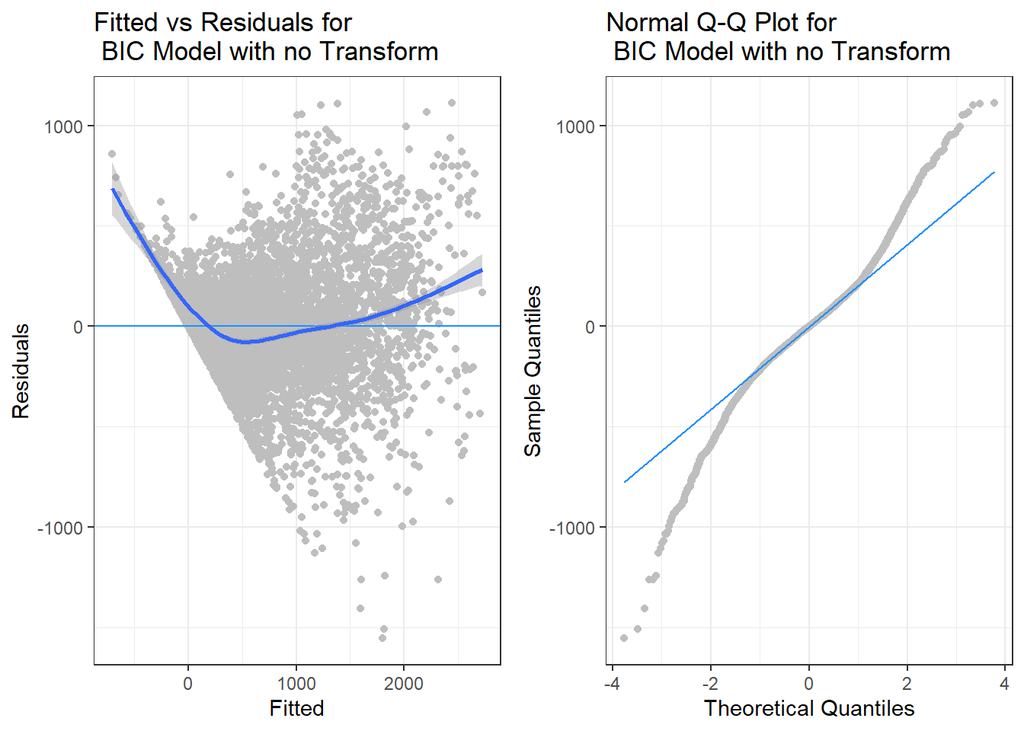

Figure 3.1: Plot 1

Table 3.2: Adjusted R^2 and Test RMSE using power transformations of response variable of BIC model (Predictions Clamped at 0)

|  | Adjusted R^2 | Test RMSE |
| --- | --- | --- |
| 0.2 | 0.849 | 264.8 |
| 0.3 | 0.854 | 257.9 |
| 0.4 | 0.857 | 253.8 |
| 0.5 | 0.858 | 251.8 |
| 0.6 | 0.857 | 251.5 |
| 0.7 | 0.855 | 252.6 |
| 0.8 | 0.851 | 255.2 |
| 0.9 | 0.846 | 259.0 |
| 1 | 0.839 | 264.2 |

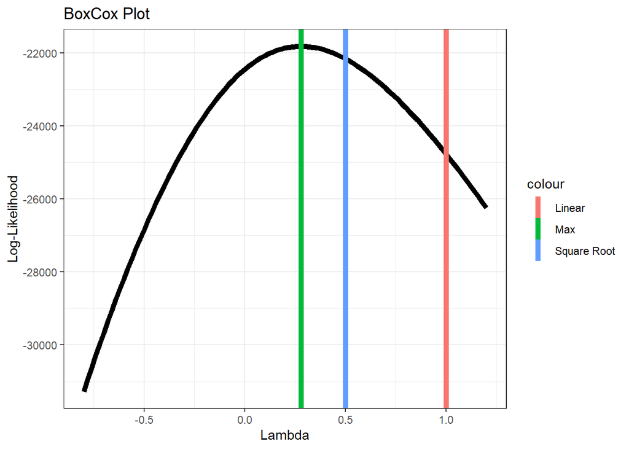

Figure 3.2: Plot 2

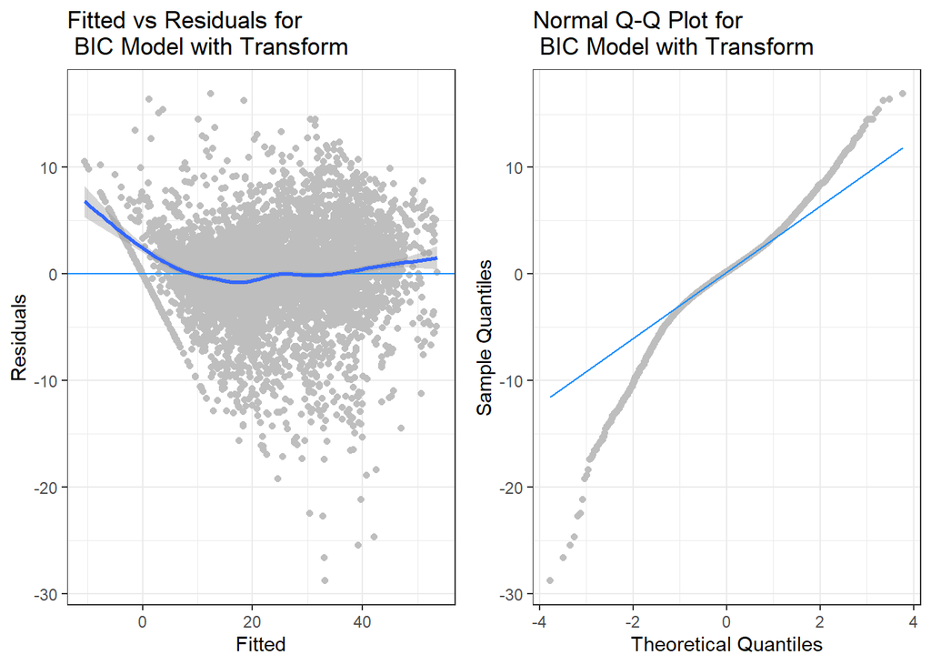

Figure 3.3: Plot 3

Table 3.3: Evaluation of Models (LOOCV-RMSE/BIC of Transformed vs Non-Transformed Not Comparable)

|  | Coefficients | LOOCV-RMSE | BIC | Test RMSE | Adjusted R2 | Test R2 |
| --- | --- | --- | --- | --- | --- | --- |
| All Interaction (Linear) | 191 | 276.4 | 87,338.9 | 268.6 | 0.833 | 0.817 |
| AIC Model (Linear) | 140 | 270.9 | 86,942.5 | 268.6 | 0.834 | 0.817 |
| BIC Model (Linear) | 99 | 271.3 | 86,754.3 | 269.7 | 0.831 | 0.816 |
| BIC Model (Sqrt Transform) | 99 | 4.7 | 36,843.1 | 251.8 | 0.860 | 0.840 |
| Selected Model (Sqrt Transform) | 130 | 4.4 | 36,064.8 | 232.8 | 0.879 | 0.863 |
| Full Model (Sqrt Transform) | 327 | 6.9 | 37,145.2 | 280.7 | 0.886 | 0.801 |

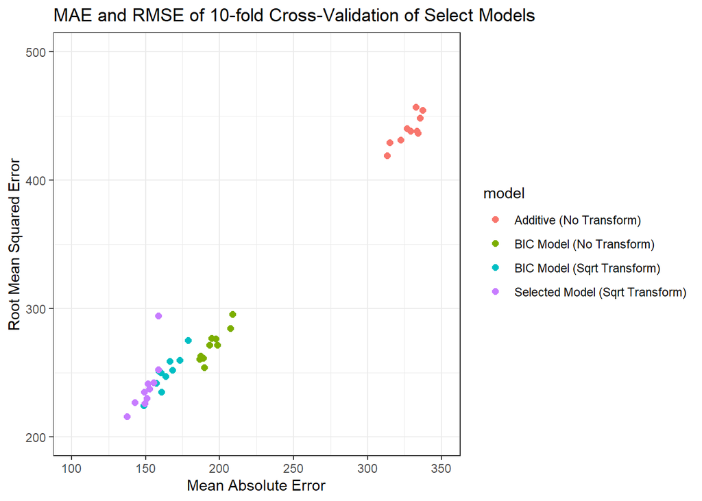

Figure 3.4: Plot 4

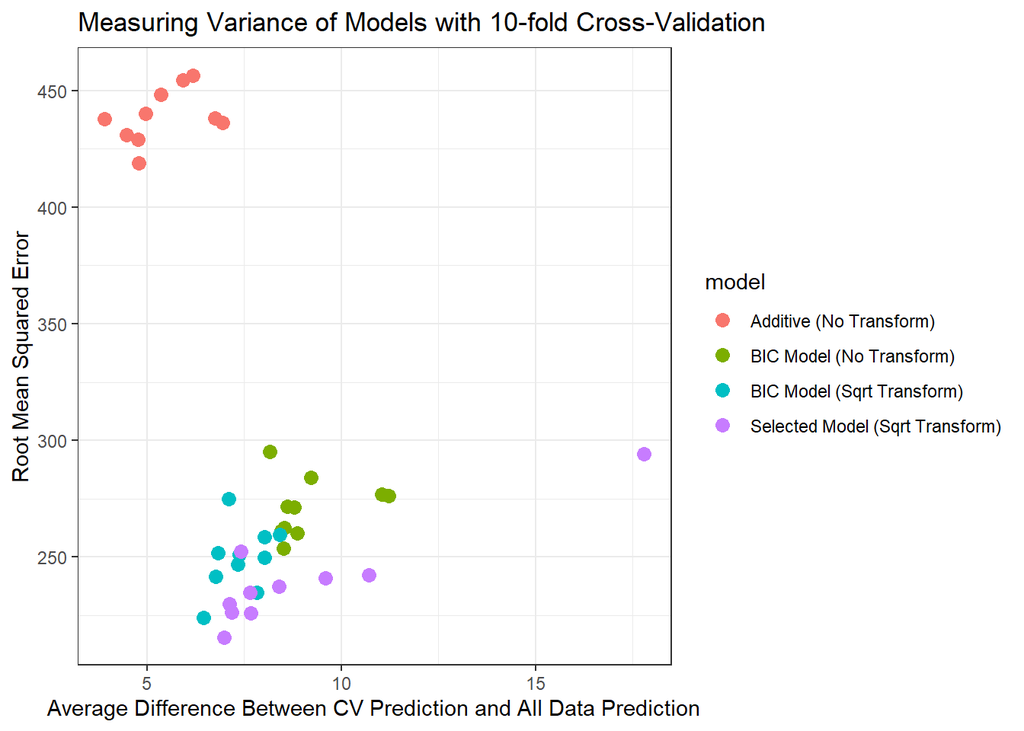

Figure 3.5: Plot 5

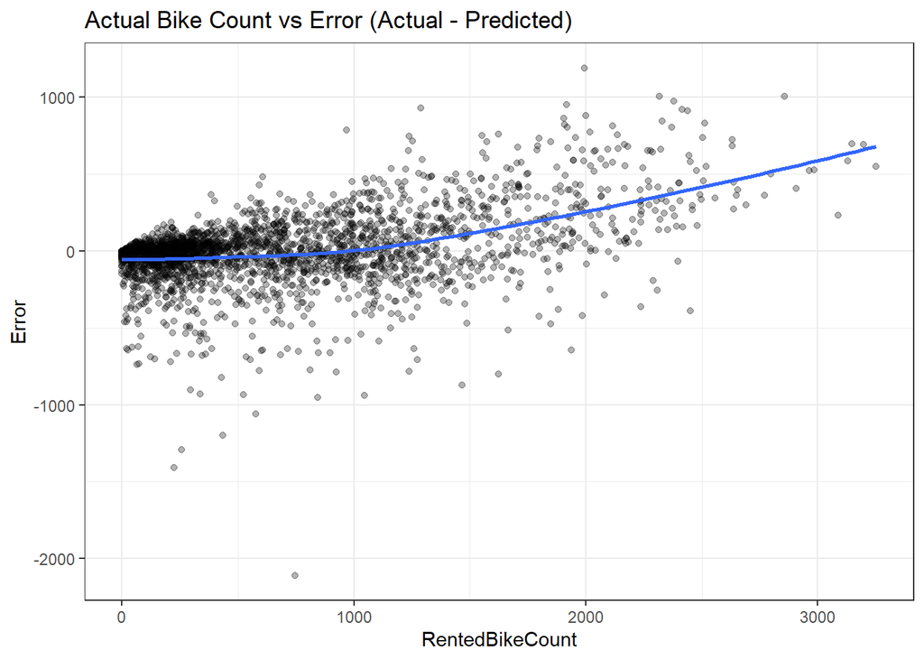

Figure 3.6: Plot 6

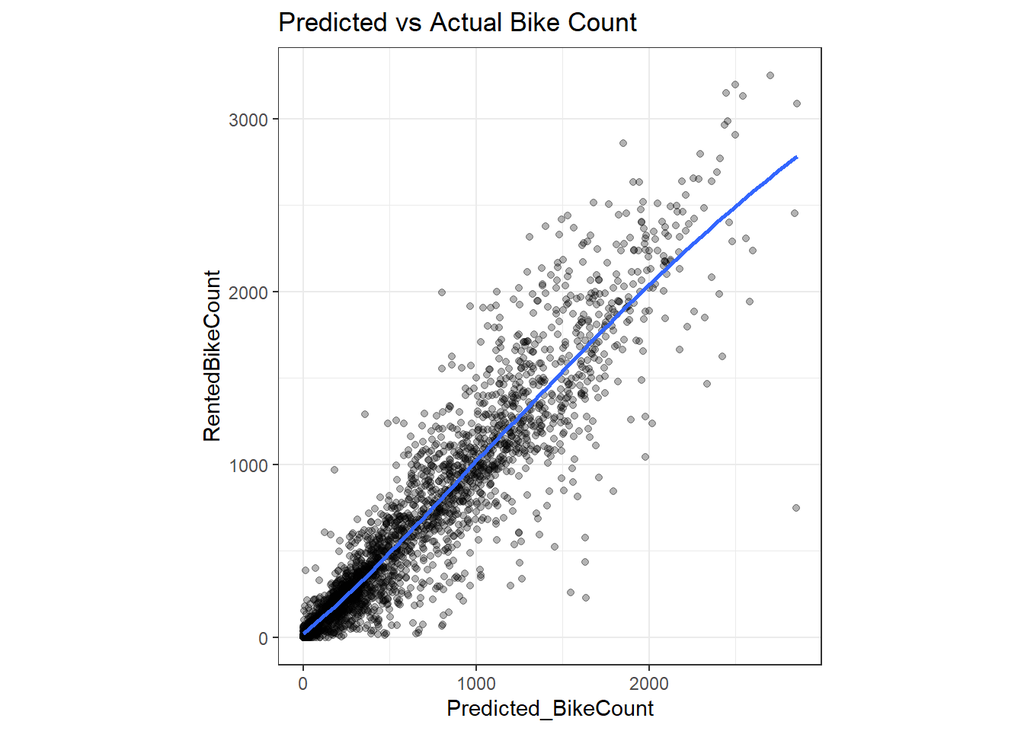

Figure 3.7: Plot 7

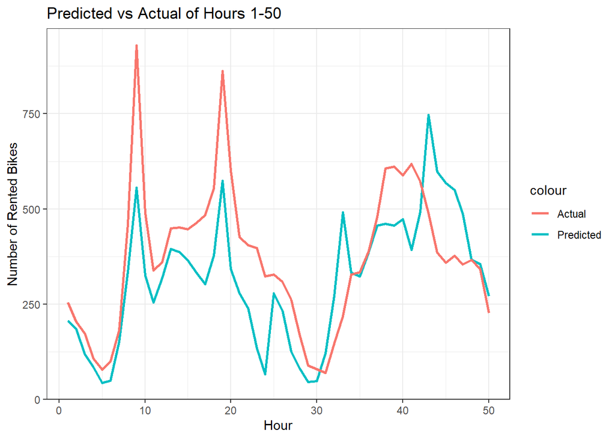

Figure 3.8: Plot 8

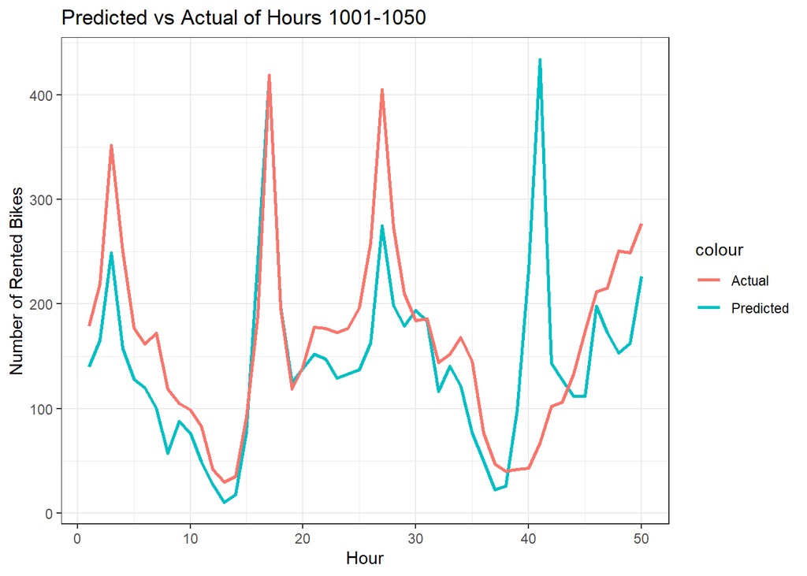

Figure 3.9: Plot 9

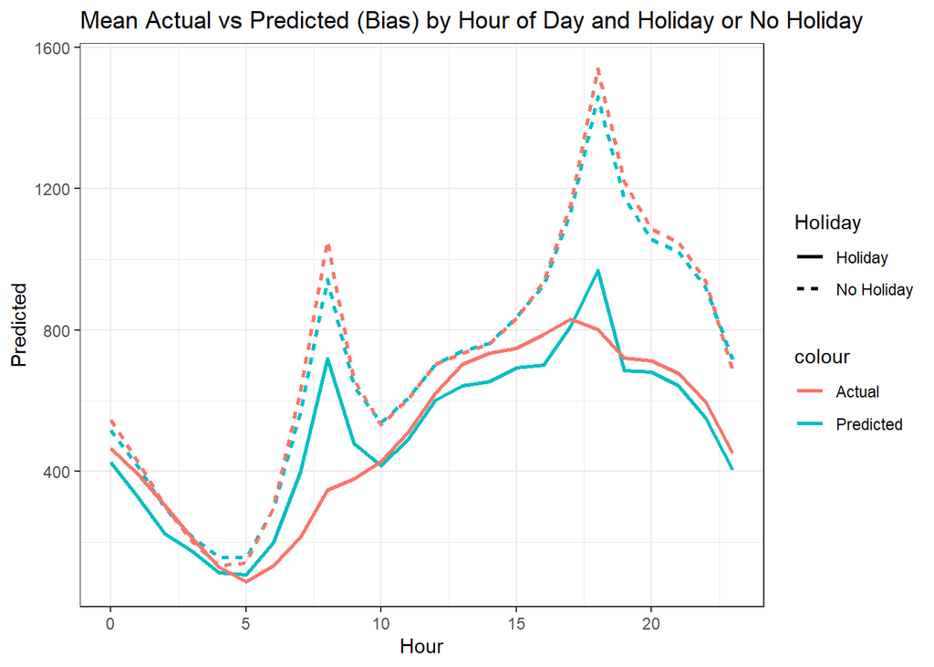

Figure 3.10: Plot 10

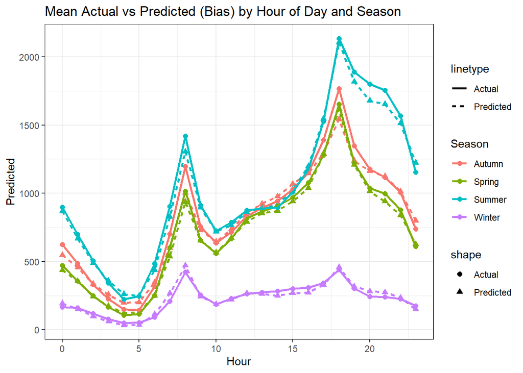

Figure 3.11: Plot 11

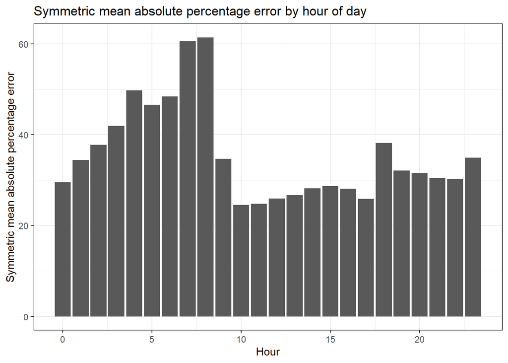

Figure 3.12: Plot 12

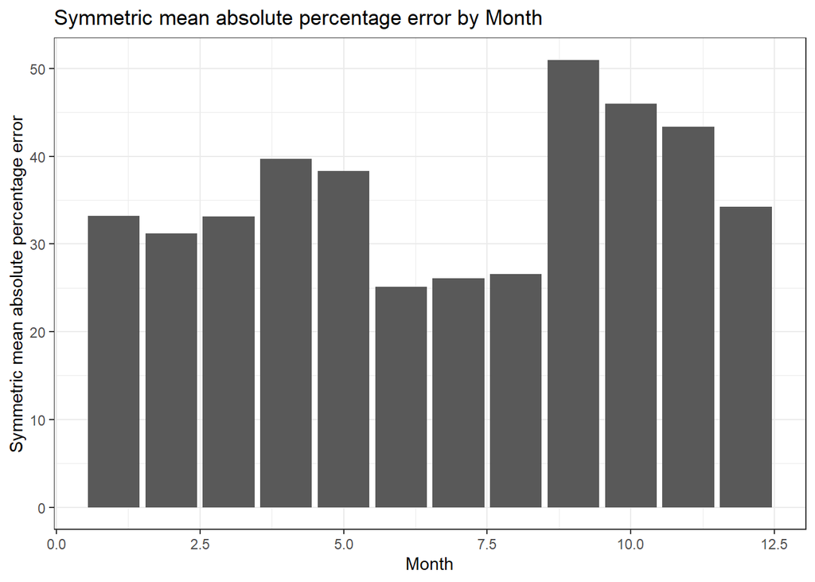

Figure 3.13: Plot 13

# 4 Discussion

In Figure 3.1 we see plot 1. In Figure 3.2 we see plot 2.

# 5 Appendix

Below is code used in the analysis, but cluttered the report. The code is re-printed here, but not evaluated, to show what was used to create, evaluate and select the model. This is primarily the code in the ‘Results’ section for various graphs/tables to illustrate how well the model runs in comparison to the actual data in the ‘Test’ dataset.

```r
table_eval1
```

```r
grid.draw(plot_diag1)
```

```r
table_transform
```

```r
plot_boxcox
```

```r
grid.draw(plot_diag2)
```

```r
table_eval2
```

```r
plot_CV
```

```r
plot_CV2
```

```r
plot_error
```

```r
plot_actual
```

```r
plot_timeline1
```

```r
plot_timeline2
```

```r
plot_hour_holidayerror
```

```r
plot_hour_seasonerror
```

```r
plot_hourerror
```

```r
plot_montherror
```